# Data Analysis

Jonathan Yuquimpo

01-11-21

## Raw Data

Snippet of data file used for analysis.  
rt: response time  
rwdType: associated value of colored item (if any)

0. No value (black)
1. Low value
2. High value

tgtPos: serial position of target item

0. 1st position
1. 2nd position
2. 3rd position
3. New item (for false alarms)

colMatch: Does the color item match the target item?

```
## # A tibble: 10,970 x 7
##    subID correct    rt rwdType tgtPos colPos colMatch
##    <fct> <lgl>   <dbl> <fct>   <chr>  <chr>  <chr>
##  1 tex   TRUE     822  2       0      0      2
##  2 tex   TRUE    1244. 2       2      0      1
##  3 tex   TRUE     698  1       2      0      1
##  4 tex   TRUE     716  2       0      0      2
##  5 tex   TRUE     667  0       1      3      0
##  6 tex   TRUE     795. 1       3      2      1
##  7 tex   TRUE     716. 1       2      1      1
##  8 tex   TRUE     733. 0       0      3      0
##  9 tex   TRUE     942. 0       0      3      0
## 10 tex   TRUE     932. 1       0      0      2
## 11 tex   TRUE     695. 0       3      3      0
## 12 tex   TRUE    1156. 1       1      0      1
## 13 tex   TRUE     801. 1       0      0      2
## 14 tex   TRUE     739. 1       3      0      1
## 15 tex   TRUE     902. 1       3      2      1
## 16 tex   TRUE     796. 0       3      3      0
## 17 tex   TRUE     709. 1       1      2      1
## 18 tex   TRUE    1357. 1       2      2      2
## 19 tex   TRUE    1403. 1       0      0      2
## 20 tex   TRUE     755. 2       0      1      1
## # ... with 10,950 more rows
```

## Filtered Data

For each participant, the number of hits, misses, false alarms, and rejections is totaled and used to compute hit rate and false alarm rate. The 1/2N correction is then applied to hit and false alarm rate which yields the HR and FA columns. Those values are then used to compute dprime and criterion for each reward condition (rwd=0, 1, or 2)

```
## # A tibble: 47 x 14
##    subID  hits  miss  fAlm  rejt hitSum hitRate    HR fAlmSum fAlmRate     FA  dprime criterion rwd
##    <fct> <int> <int> <int> <int>  <int>   <dbl> <dbl>   <int>    <dbl>  <dbl>   <dbl>     <dbl> <fct>
##  1 111      18     0     2    33     18   1     0.972      35   0.0571 0.0571  3.49      -0.168 1
##  2 13z      12     6     8    28     18   0.667 0.667      36   0.222  0.222   1.20       0.167 1
##  3 15n      15     3    13    23     18   0.833 0.833      36   0.361  0.361   1.32      -0.306 1
##  4 2cb      15     3     6    30     18   0.833 0.833      36   0.167  0.167   1.93       0     1
##  5 30r      12     6     6    30     18   0.667 0.667      36   0.167  0.167   1.40       0.268 1
##  6 42y      11     7     7    29     18   0.611 0.611      36   0.194  0.194   1.14       0.290 1
##  7 5hn      10     6     8    24     16   0.625 0.625      32   0.25   0.25    0.993      0.178 1
##  8 5qj      16     1     9    27     17   0.941 0.941      36   0.25   0.25    2.24      -0.445 1
##  9 78w      10     7    19    13     17   0.588 0.588      32   0.594  0.594  -0.0142    -0.230 1
## 10 9gt      18     0     2    34     18   1     0.972      36   0.0556 0.0556  3.51      -0.161 1
## # ... with 37 more rows
```

```
## # A tibble: 47 x 14
##    subID  hits  miss  fAlm  rejt hitSum hitRate    HR fAlmSum fAlmRate    FA dprime criterion rwd
##    <fct> <int> <int> <int> <int>  <int>   <dbl> <dbl>   <int>    <dbl> <dbl>  <dbl>     <dbl> <fct>
##  1 111      17     1     4    32     18   0.944 0.944      36    0.111 0.111  2.81    -0.186  2
##  2 13z      15     3     5    31     18   0.833 0.833      36    0.139 0.139  2.05     0.0590 2
##  3 15n      16     2    12    24     18   0.889 0.889      36    0.333 0.333  1.65    -0.395  2
##  4 2cb      17     1     5    31     18   0.944 0.944      36    0.139 0.139  2.68    -0.254  2
##  5 30r      15     3     5    31     18   0.833 0.833      36    0.139 0.139  2.05     0.0590 2
##  6 42y      13     5    12    24     18   0.722 0.722      36    0.333 0.333  1.02    -0.0794 2
##  7 5hn      12     4     4    29     16   0.75  0.75       33    0.121 0.121  1.84     0.247  2
##  8 5qj      12     6     9    27     18   0.667 0.667      36    0.25  0.25   1.11     0.122  2
##  9 78w       3     9    10    22     12   0.25  0.25       32    0.312 0.312 -0.186    0.582  2
## 10 9gt      17     1     6    30     18   0.944 0.944      36    0.167 0.167  2.56    -0.313  2
## # ... with 37 more rows
```

```
## # A tibble: 47 x 14
##    subID  hits  miss  fAlm  rejt hitSum hitRate    HR fAlmSum fAlmRate     FA dprime criterion rwd
##    <fct> <int> <int> <int> <int>  <int>   <dbl> <dbl>   <int>    <dbl>  <dbl>  <dbl>     <dbl> <fct>
##  1 111      12     0     1    23     12   1     0.958      24   0.0417 0.0417  3.46  -2.22e-16 0
##  2 13z      10     2     4    20     12   0.833 0.833      24   0.167  0.167   1.93   0        0
##  3 15n      10     2     4    20     12   0.833 0.833      24   0.167  0.167   1.93   0        0
##  4 2cb      11     1     6    17     12   0.917 0.917      23   0.261  0.261   2.02  -3.71e- 1 0
##  5 30r      11     1     2    22     12   0.917 0.917      24   0.0833 0.0833  2.77   3.33e-16 0
##  6 42y      10     2     4    20     12   0.833 0.833      24   0.167  0.167   1.93   0        0
##  7 5hn       6     6     3    19     12   0.5   0.5        22   0.136  0.136   1.10   5.48e- 1 0
##  8 5qj       8     4     7    17     12   0.667 0.667      24   0.292  0.292   0.979  5.89e- 2 0
##  9 78w       5     7     6    13     12   0.417 0.417      19   0.316  0.316   0.269  3.45e- 1 0
## 10 9gt      10     2     5    19     12   0.833 0.833      24   0.208  0.208   1.78  -7.76e- 2 0
## # ... with 37 more rows
```

## Computations for graphs

For each variable, standard error is computed within-subjects using the Rmisc package. See here for more info

```
##   rwd      mean         sd          se         ci        condition
## 1   2 0.7497730 0.12950613 0.018890411 0.03802443         Hit Rate
## 2   1 0.7689435 0.11773524 0.017173449 0.03456836         Hit Rate
## 3   0 0.7756401 0.11652836 0.016997409 0.03421401         Hit Rate
## 4   2 0.2100529 0.06686386 0.009753096 0.01963196 False Alarm Rate
## 5   1 0.2232681 0.07725404 0.011268660 0.02268264 False Alarm Rate
## 6   0 0.2186266 0.08188079 0.011943541 0.02404110 False Alarm Rate
```

```
##   rwd  N   dprime        sd         se        ci
## 1   2 47 1.633508 0.5477724 0.07990082 0.1608320
## 2   1 47 1.686386 0.5492949 0.08012290 0.1612790
## 3   0 47 1.718067 0.4979641 0.07263552 0.1462077
```

```
##   rwd  N   criterion        sd         se         ci
## 1   2 47  0.05555201 0.2499850 0.03646406 0.07339834
## 2   1 47 -0.02157579 0.2616152 0.03816049 0.07681309
## 3   0 47 -0.00532723 0.2652444 0.03868988 0.07787868
```

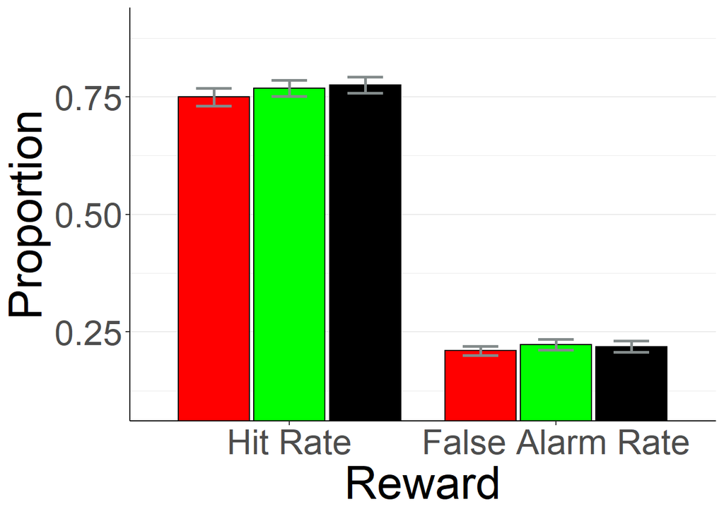

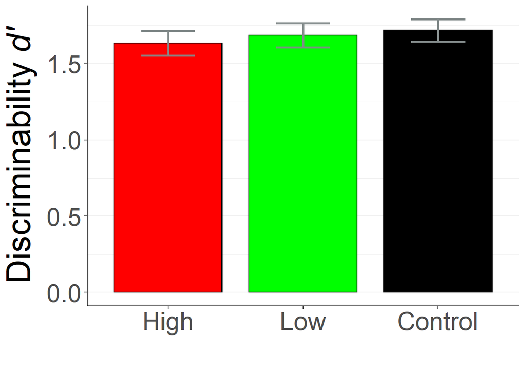

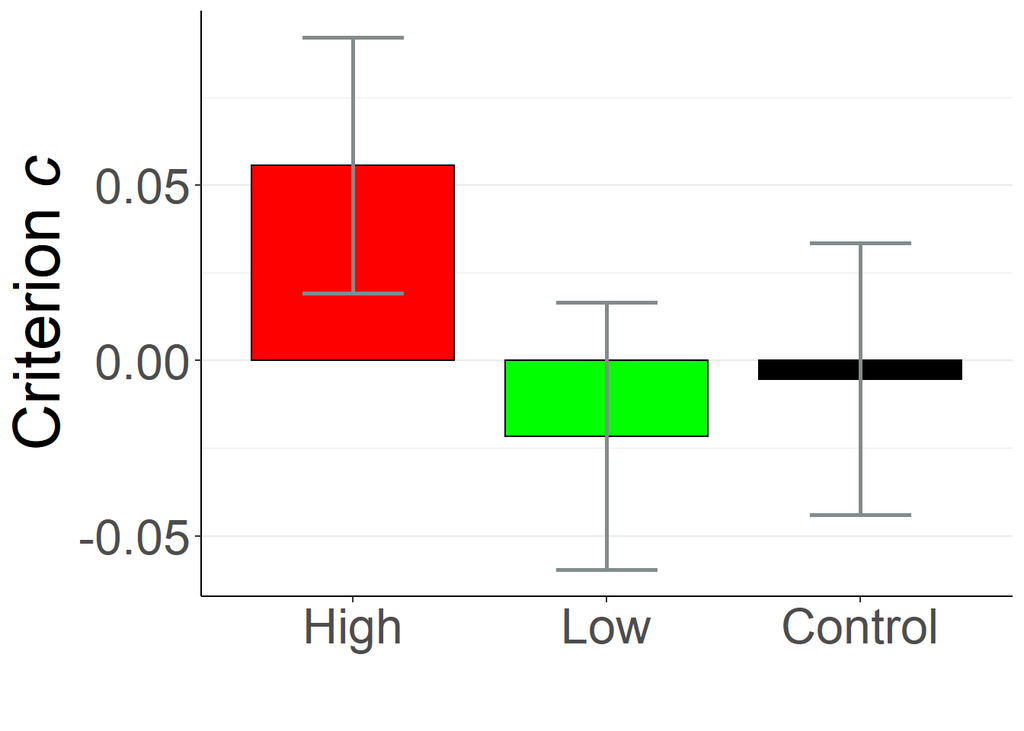